# Identifying weather events with highest impact on health and damages

### Synopsis

This report addresses the question, which types of weather events are 1) most harmful with respect to population health and 2) have the greatest economic consequences across the United States. To answer these questions, data from the U.S. National Oceanic and Atmospheric Administration’s (NOAA) storm database from 1950 to 2011 is used.

The data processing consists of removing unnecessary variables, making the damage costs comparable, creating two new variables that sum up the consequences to population health and economic consequences and summarizing the effects of weather events grouped by event type. With this processed data, pareto charts containing the TOP 5 weather events for each consequence in question (injuries, fatalities and the sum of these as well as damage to property and crop and the sum of those) are prepared.

The TOP 3 events most harmful for population health are tornados, excessive heat and TSTM wind. The TOP 3 events with the greatest economic consequences are flood, hurricane/typhoon and tornados. For details see result section.

### Data Processing

The analysis is done with data on weather events from 1950 to 2011 from the U.S. National Oceanic and Atmospheric Administration’s (NOAA) storm database.

```r
library(lubridate)

# download the data if necessary
if ((!file.exists("StormData.csv")) & (!file.exists("StormData.csv.bz2"))){
        download.file("https://d396qusza40orc.cloudfront.net/repdata%2Fdata%2FStormData.csv.bz2",
                      "StormData.csv.bz2")
        now()
}
```

```
## [1] "2017-05-09 21:21:58 CEST"
```

```r
# read in the data
if (!file.exists("StormData.csv")){
        storm_data<-read.csv("StormData.csv.bz2", header=TRUE)
} else {
        storm_data<-read.csv("StormData.csv", header=TRUE)
}

# Dimensions of data set
dim(storm_data)
```

```
## [1] 902297     37
```

Explanation on the variables used in the downloaded data set can be found here: https://d396qusza40orc.cloudfront.net/repdata%2Fpeer2_doc%2Fpd01016005curr.pdf

To answer the questions above, only the columns EVTYPE (event type), FATALITIES and INJURIES for the first question and PROPDMG (property damage), PROPDMGEXP, CROPDMG (crop damage) and CROPDMGEXP for the second question are needed. All other 30 columns are deleted, the remaining column names are converted to lowercase.

```r
# only relevant columns are kept
storm_data<-storm_data[,c(8, 23:28)]

# for easier use all names are converted to lower
names(storm_data)<-tolower(names(storm_data))
```

The variables propdmg and cropdmg are coded in varying units. If variable propdmgexp/cropdmgexp equals “K” the value is given in thousand $, for “M” in million $ and for “B” in billion $. The variables “prop_mult” and “crop_mult” are temporarily created and filled with the number the costs need to be multiplied to make them comparable. After the adjusting of the costs for the damages the temporary variables are deleted.

To complete the data set, afterwards two new variables are added: “health” to sum up the number of fatalities and injuries and “damage” to sum up the adjusted costs of property damage and crop damage. The data is then grouped by the event type and the effects to population health and the economic consequences are summarized by group.

```r
library(dplyr)

# creation of temporary variables for multiplication of damage costs
storm_data<-mutate(storm_data, prop_mult = ifelse(propdmgexp=="K", yes=1000,
                                                no=(ifelse(propdmgexp=="M", yes=1000000,
                                                         no=(ifelse(propdmgexp=="B", yes=1000000000, no=1))))))

storm_data<-mutate(storm_data, crop_mult = ifelse(cropdmgexp=="K", yes=1000,
                                                no=(ifelse(cropdmgexp=="M", yes=1000000,
                                                         no=(ifelse(cropdmgexp=="B", yes=1000000000, no=1))))))

# costs for damages are adjusted by multiplying with prop_mult and crop_mult
storm_data<-mutate(storm_data, propdmg=propdmg*prop_mult, cropdmg=cropdmg*crop_mult)

# temporary variables prop_mult and crop_mult are deleted
storm_data<-storm_data[,c(1:4,6)]

# summarizing variables are added
storm_data<-mutate(storm_data, health=fatalities+injuries, damage=propdmg+cropdmg)

# data is grouped by event type and consequences on population health and costs for
# damages are summarized per event type
data_grouped<-group_by(storm_data,evtype)
sums<-summarize_all(data_grouped, sum)
```

The resulting data set already directly contains the information to answer the questions.

The following pareto charts containing the TOP 5 weather events for each weather consequence in question serve as a basis for a prioritization on which severe weather events to prepare first:

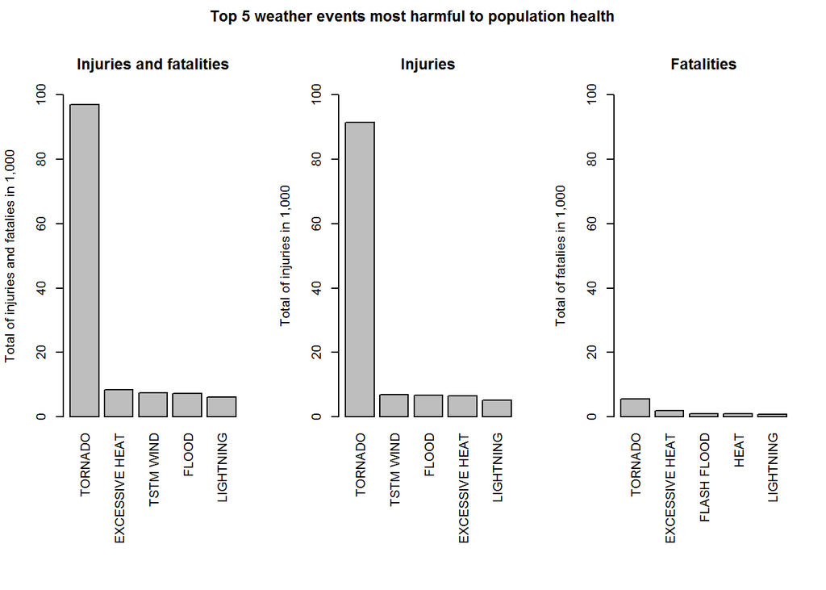

```r
# creating data sets in decreasing order for each weather consequence in question
# only TOP 5 are used for pareto charts

# population health
health5<-sums[order(sums$health,decreasing=TRUE),][1:5,]
injur5<-sums[order(sums$injuries,decreasing=TRUE),][1:5,]
fatal5<-sums[order(sums$fatalities,decreasing=TRUE),][1:5,]

# costs for damages
dmg5<-sums[order(sums$damage,decreasing=TRUE),][1:5,]
prop5<-sums[order(sums$propdmg,decreasing=TRUE),][1:5,]
crop5<-sums[order(sums$cropdmg,decreasing=TRUE),][1:5,]

# creation of pareto charts as 2 sets of barplots
par(mfrow=c(1,3), las=3, mar=c(9.1, 4.1, 4.1, 2.1), oma=c(2,0,2,0))

# population health
barplot(height=health5$health/1000,names.arg=health5$evtype,
        ylab="Total of injuries and fatalies in 1,000", ylim=c(0,100))
title("Injuries and fatalities")

barplot(height=injur5$injuries/1000,names.arg=injur5$evtype,
        ylab="Total of injuries in 1,000", ylim=c(0,100))
title("Injuries")

barplot(height=fatal5$fatalities/1000,names.arg=fatal5$evtype,
        ylab="Total of fatalies in 1,000", ylim=c(0,100))
title("Fatalities")

title("Top 5 weather events most harmful to population health", outer=TRUE)
```

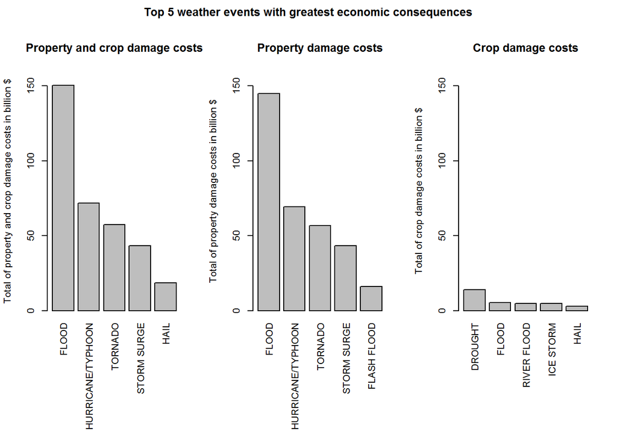

```r
# costs for damages
barplot(height=dmg5$damage/1000000000,names.arg=dmg5$evtype,
        ylab="Total of property and crop damage costs in billion $", ylim=c(0,160))
title("Property and crop damage costs")

barplot(height=prop5$propdmg/1000000000,names.arg=prop5$evtype,
        ylab="Total of property damage costs in billion $", ylim=c(0,160))
title("Property damage costs")

barplot(height=crop5$cropdmg/1000000000,names.arg=crop5$evtype,
        ylab="Total of crop damage costs in billion $", ylim=c(0,160))
title("Crop damage costs")

title("Top 5 weather events with greatest economic consequences", outer=TRUE)
```

### Results

The pareto charts show that tornados are - by far - the weather events most harmful to population health. Combining injuries and fatalities, excessive heat and TSTM wind are on second and third place, but effects of tornados are a lot larger.

Looking at injuries only, TSTM wind is on second place following tornados and flood takes the third place.

For fatalities excessive heat is on second place following tornados, flash floods are on third place.

The greatest economic consequences concerning property and crop damage costs are caused by flood. The weather event on second place is hurricane/typhoon which causes about half of the costs of flood. On third place are tornados.

The ranking is the same when only looking at the costs for property damage.

In contrast, for crop damage costs drought is the most harmful weather event, followed by flood and river flood.